# More on shrinkage plots

Author

Phillip Alday, Douglas Bates, and Reinhold Kliegl

Published

2026-03-31

- I have stated that the likelihood criterion used to fit linear mixed-effects can be considered as balancing fidelity to the data (i.e. fits the observed data well) versus model complexity.
- This is similar to some of the criterion used in Machine Learning (ML), except that the criterion for LMMs has a rigorous mathematical basis.
- In the shrinkage plot we consider the values of the random-effects coefficients for the fitted values of the model versus those from a model in which there is no penalty for model complexity.
- If there is strong subject-to-subject variation then the model fit will tend to values of the random effects similar to those without a penalty on complexity.
- If the random effects term is not contributing much (i.e. it is “inert”) then the random effects will be *shrunk* considerably towards zero in some directions.

```julia
using CairoMakie
using DataFrames
using LinearAlgebra
using MixedModels
using MixedModelsMakie
using Random
using ProgressMeter
using SMLP2026: fit_or_restore

const progress = false
```

```
false
```

Load the kb07 data set (don’t tell Reinhold that I used these data).

```julia
kb07 = MixedModels.dataset(:kb07)
```

```
Arrow.Table with 1789 rows, 7 columns, and schema:
 :subj      String
 :item      String
 :spkr      String
 :prec      String
 :load      String
 :rt_trunc  Int16
 :rt_raw    Int16
```

```julia
contrasts = Dict(
  :spkr => HelmertCoding(),
  :prec => HelmertCoding(),
  :load => HelmertCoding(),
)
m1 = let
  form = @formula(
    rt_trunc ~
      1 +
      spkr * prec * load +
      (1 + spkr + prec + load | subj) +
      (1 + spkr + prec + load | item)
  )
  fit(MixedModel, form, kb07; contrasts, progress)
end
```

```julia
VarCorr(m1)
```

|  | Column | Variance | Std.Dev | Corr. |  |  |
| --- | --- | --- | --- | --- | --- | --- |
| subj | (Intercept) | 91064.7403 | 301.7693 |  |  |  |
|  | spkr: old | 1850.5250 | 43.0177 | +0.78 |  |  |
|  | prec: maintain | 3843.8825 | 61.9991 | -0.59 | +0.03 |  |
|  | load: yes | 4246.0532 | 65.1617 | +0.36 | +0.83 | +0.53 |
| item | (Intercept) | 131173.0381 | 362.1782 |  |  |  |
|  | spkr: old | 1656.7129 | 40.7027 | +0.44 |  |  |
|  | prec: maintain | 60946.6098 | 246.8737 | -0.69 | +0.35 |  |
|  | load: yes | 1795.0255 | 42.3677 | +0.32 | +0.16 | -0.14 |
| Residual |  | 446886.0133 | 668.4953 |  |  |  |

```julia
issingular(m1)
```

```
true
```

```julia
print(m1)
```

```
Linear mixed model fit by maximum likelihood
 rt_trunc ~ 1 + spkr + prec + load + spkr & prec + spkr & load + prec & load + spkr & prec & load + (1 + spkr + prec + load | subj) + (1 + spkr + prec + load | item)
    logLik   -2 logLik      AIC         AICc        BIC
 -14318.5613  28637.1227  28695.1227  28696.1119  28854.3156

Variance components:
             Column       Variance  Std.Dev.   Corr.
subj     (Intercept)      91064.7403 301.7693
         spkr: old         1850.5250  43.0177 +0.78
         prec: maintain    3843.8825  61.9991 -0.59 +0.03
         load: yes         4246.0532  65.1617 +0.36 +0.83 +0.53
item     (Intercept)     131173.0381 362.1782
         spkr: old         1656.7129  40.7027 +0.44
         prec: maintain   60946.6098 246.8737 -0.69 +0.35
         load: yes         1795.0255  42.3677 +0.32 +0.16 -0.14
Residual                 446886.0133 668.4953
 Number of obs: 1789; levels of grouping factors: 56, 32

  Fixed-effects parameters:
───────────────────────────────────────────────────────────────────────────────
                                             Coef.  Std. Error      z  Pr(>|z|)
───────────────────────────────────────────────────────────────────────────────
(Intercept)                             2181.67        77.299   28.22    <1e-99
spkr: old                                 67.7485      18.2934   3.70    0.0002
prec: maintain                          -333.921       47.1493  -7.08    <1e-11
load: yes                                 78.7703      19.5383   4.03    <1e-04
spkr: old & prec: maintain               -21.9657      15.806   -1.39    0.1646
spkr: old & load: yes                     18.3843      15.806    1.16    0.2448
prec: maintain & load: yes                 4.53389     15.806    0.29    0.7742
spkr: old & prec: maintain & load: yes    23.6074      15.806    1.49    0.1353
───────────────────────────────────────────────────────────────────────────────
```

## 1 Expressing the covariance of random effects

Earlier today we mentioned that the parameters being optimized are from a “matrix square root” of the covariance matrix for the random effects. There is one such lower triangular matrix for each grouping factor.

```julia
l1 = first(m1.λ)   # Cholesky factor of relative covariance for subj
```

```
4×4 LowerTriangular{Float64, Matrix{Float64}}:
  0.451416    ⋅          ⋅          ⋅
  0.0502725  0.0401697   ⋅          ⋅
 -0.0550321  0.0726579  0.01714     ⋅
  0.0351643  0.0850281  0.0321733  0.0
```

Notice the zero on the diagonal. A triangular matrix with zeros on the diagonal is singular.

```julia
l2 = last(m1.λ)    # this one is also singular
```

```
4×4 LowerTriangular{Float64, Matrix{Float64}}:
  0.541781    ⋅           ⋅          ⋅
  0.0268651  0.0546398    ⋅          ⋅
 -0.253039   0.268006    0.0229063   ⋅
  0.0200358  0.00129292  0.0601135  0.0
```

To regenerate the covariance matrix we need to know that the covariance is not the *square* of `l1`, it is `l1 * l1'` (so that the result is symmetric) and multiplied by σ̂²

```julia
Σ₁ = varest(m1) .* (l1 * l1')
```

```
4×4 Matrix{Float64}:
  91064.7   10141.5     -11101.7     7093.74
  10141.5    1850.52        67.9472  2316.37
 -11101.7      67.9472    3843.88    2142.48
   7093.74   2316.37      2142.48    4246.05
```

```julia
diag(Σ₁)  # compare to the variance column in the VarCorr output
```

```
4-element Vector{Float64}:
 91064.74027228545
  1850.5249616692
  3843.882496563724
  4246.0532111504635
```

```julia
sqrt.(diag(Σ₁))
```

```
4-element Vector{Float64}:
 301.76934945796836
  43.017728457802136
  61.9990523844012
  65.16174653238251
```

## 2 Shrinkage plots

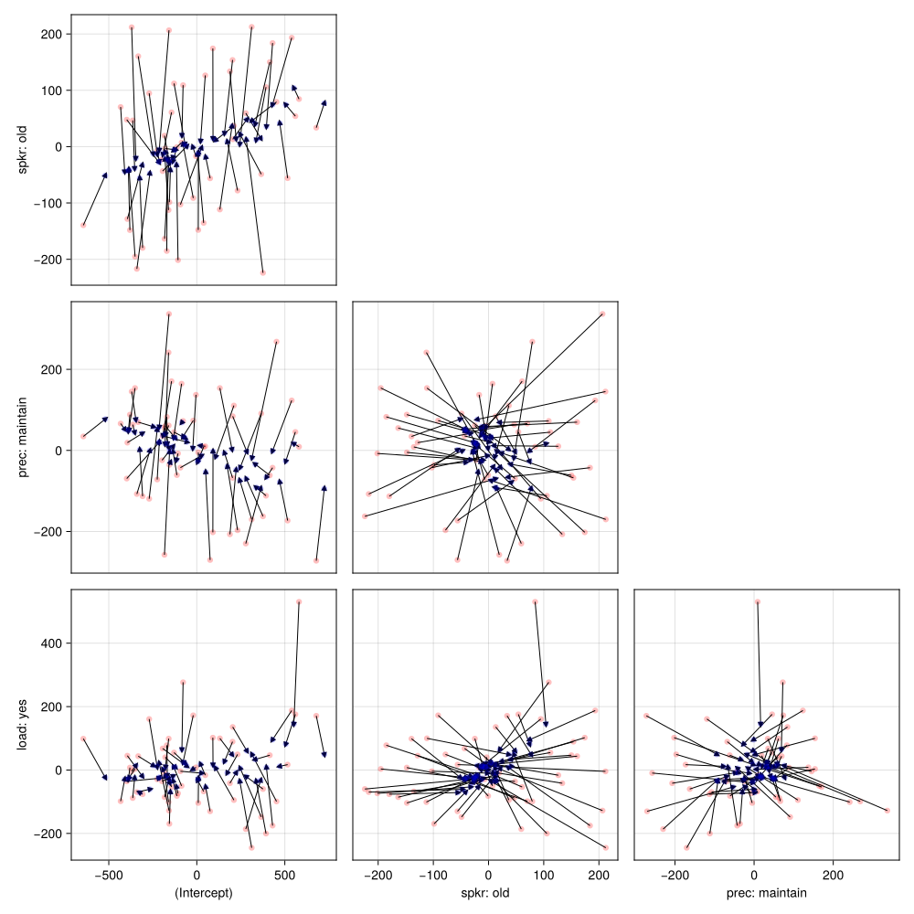

Figure 1: Shrinkage plot of model m1

```julia
shrinkageplot(m1)
```

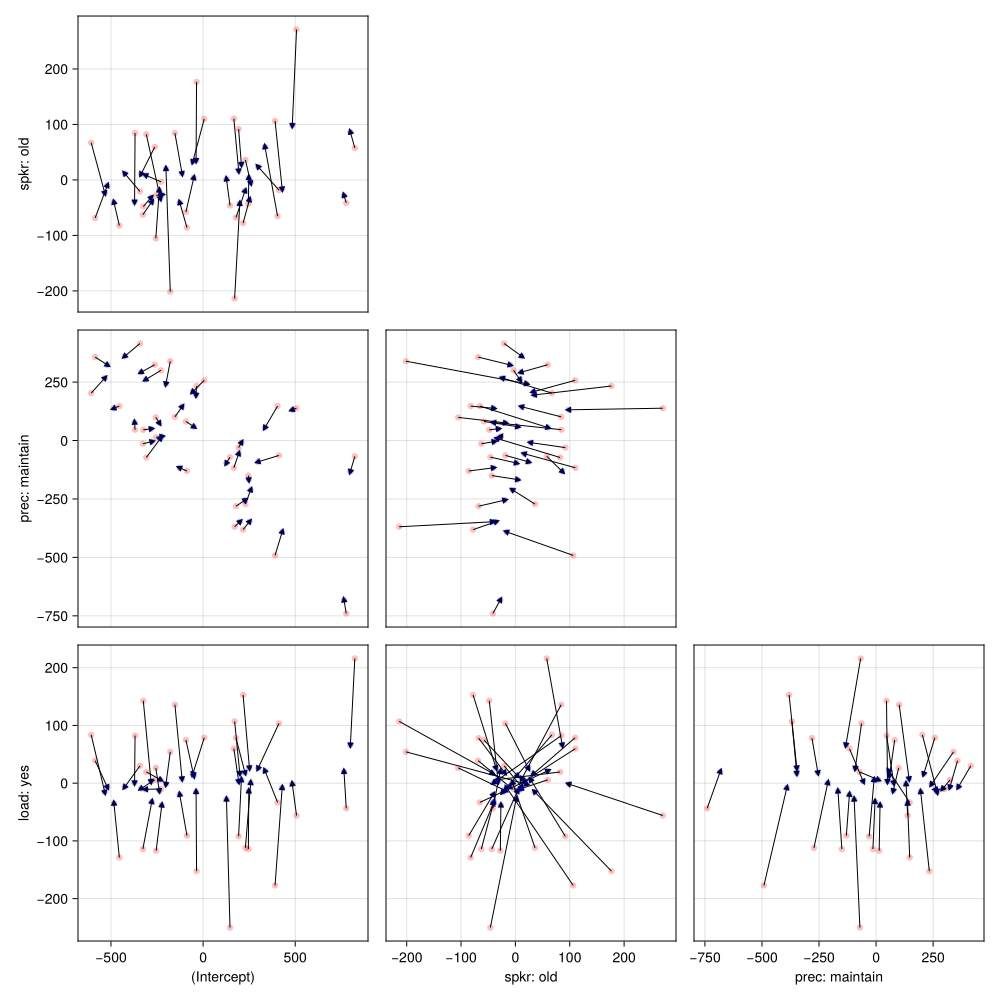

```julia
shrinkageplot(m1, :item)
```

```julia
X1 = Int.(m1.X')
```

```
8×1789 Matrix{Int64}:
  1   1   1   1   1  1   1   1   1   1  …   1   1   1   1   1   1   1  1   1
 -1   1   1  -1  -1  1   1  -1  -1   1      1  -1  -1   1   1  -1  -1  1   1
 -1   1  -1   1  -1  1  -1   1  -1   1     -1   1  -1   1  -1   1  -1  1  -1
  1  -1  -1  -1  -1  1   1   1   1  -1      1   1   1  -1  -1  -1  -1  1   1
  1   1  -1  -1   1  1  -1  -1   1   1     -1  -1   1   1  -1  -1   1  1  -1
 -1  -1  -1   1   1  1   1  -1  -1  -1  …   1  -1  -1  -1  -1   1   1  1   1
 -1  -1   1  -1   1  1  -1   1  -1  -1     -1   1  -1  -1   1  -1   1  1  -1
  1  -1   1   1  -1  1  -1  -1   1  -1     -1  -1   1  -1   1   1  -1  1  -1
```

```julia
X1 * X1'
```

```
8×8 Matrix{Int64}:
 1789    -1    -1     3    -3     1     1     3
   -1  1789    -3     1    -1     3     3     1
   -1    -3  1789     1    -1     3     3     1
    3     1     1  1789     3    -1    -1    -3
   -3    -1    -1     3  1789     1     1     3
    1     3     3    -1     1  1789    -3    -1
    1     3     3    -1     1    -3  1789    -1
    3     1     1    -3     3    -1    -1  1789
```

## 3 How to interpret a shrinkage plot

- Extreme shrinkage (shrunk to a line or to a point) is easy to interpret – the term is not providing benefit and can be removed.
- When the range of the blue dots (shrunk values) is comparable to those of the red dots (unshrunk) it indicates that the term after shrinkage is about as strong as without shrinkage.
- By itself, this doesn’t mean that the term is important. In some ways you need to get a feeling for the absolute magnitude of the random effects in addition to the relative magnitude.
- Small magnitude and small relative magnitude indicate you can drop that term

## 4 Conclusions from these plots

```julia
m2 = let
  form = @formula(
    rt_trunc ~
      1 + prec * spkr * load + (1 | subj) + (1 + prec | item)
  )
  fit(MixedModel, form, kb07; contrasts, progress)
end
```

```julia
VarCorr(m2)
```

|  | Column | Variance | Std.Dev | Corr. |
| --- | --- | --- | --- | --- |
| item | (Intercept) | 133027.438 | 364.729 |  |
|  | prec: maintain | 63841.835 | 252.669 | -0.70 |
| subj | (Intercept) | 88870.014 | 298.111 |  |
| Residual |  | 460948.573 | 678.932 |  |

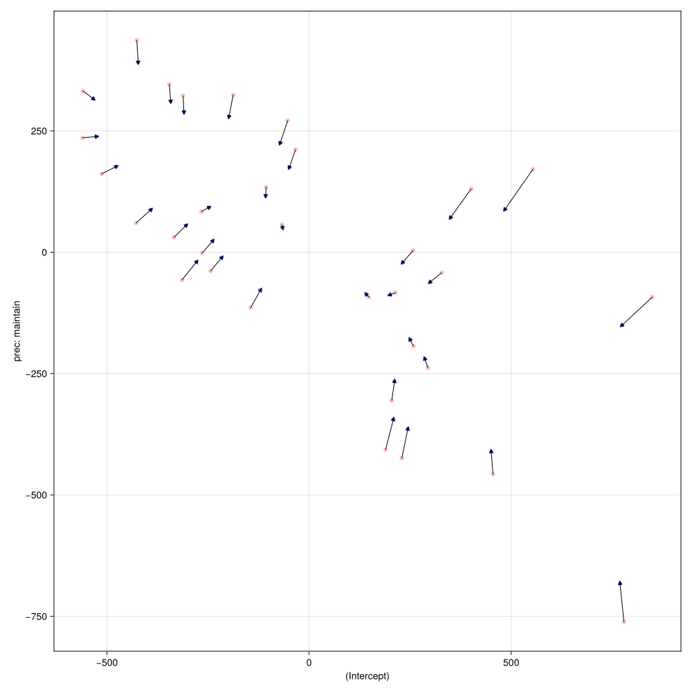

Figure 2: Shrinkage plot of model m2

```julia
shrinkageplot(m2)
```

```julia
m3 = let
  form = @formula(
    rt_trunc ~
      1 + prec + spkr + load + (1 | subj) + (1 + prec | item)
  )
  fit(MixedModel, form, kb07; contrasts, progress)
end
```

```julia
VarCorr(m3)
```

|  | Column | Variance | Std.Dev | Corr. |
| --- | --- | --- | --- | --- |
| item | (Intercept) | 133014.905 | 364.712 |  |
|  | prec: maintain | 63768.184 | 252.524 | -0.70 |
| subj | (Intercept) | 88819.302 | 298.026 |  |
| Residual |  | 462443.261 | 680.032 |  |

```julia
rng = Random.seed!(1234321);
```

```julia
m3btstrp = parametricbootstrap(rng, 2000, m3);
```

```julia
DataFrame(shortestcovint(m3btstrp))
```

9×5 DataFrame

| Row | type String | group String? | names String? | lower Float64 | upper Float64 |
| --- | --- | --- | --- | --- | --- |
| 1 | β | missing | (Intercept) | 2022.91 | 2334.0 |
| 2 | β | missing | prec: maintain | -430.239 | -239.802 |
| 3 | β | missing | spkr: old | 34.0592 | 96.72 |
| 4 | β | missing | load: yes | 46.5349 | 109.526 |
| 5 | σ | item | (Intercept) | 270.065 | 451.979 |
| 6 | σ | item | prec: maintain | 181.739 | 325.127 |
| 7 | ρ | item | (Intercept), prec: maintain | -0.907255 | -0.490094 |
| 8 | σ | subj | (Intercept) | 233.834 | 364.504 |
| 9 | σ | residual | missing | 657.341 | 702.655 |

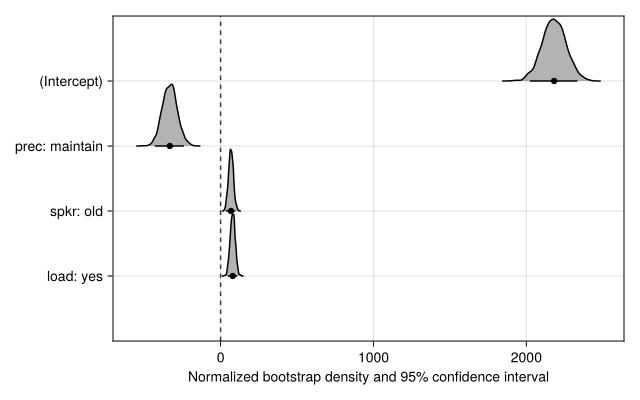

Figure 3: Ridge plot of the fixed-effects coefficients from the bootstrap sample

```julia
ridgeplot(m3btstrp)
```

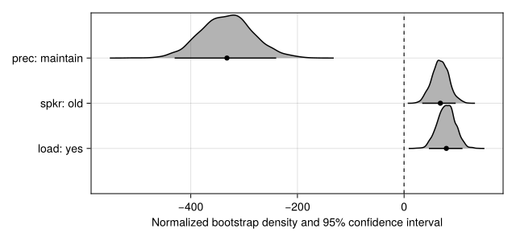

```julia
ridgeplot(m3btstrp; show_intercept=false)
```

```julia
m4 = let
  form = @formula(
    rt_trunc ~
      1 + prec + spkr + load + (1 + prec | item) + (1 | subj)
  )
  fit(MixedModel, form, kb07; contrasts, progress)
end
```

```julia
m4bstrp = parametricbootstrap(rng, 2000, m4);
```

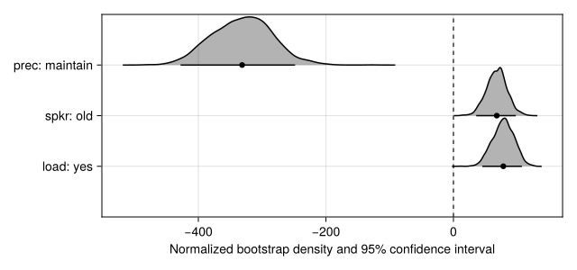

```julia
ridgeplot(m4bstrp; show_intercept=false)
```

```julia
DataFrame(shortestcovint(m4bstrp))
```

9×5 DataFrame

| Row | type String | group String? | names String? | lower Float64 | upper Float64 |
| --- | --- | --- | --- | --- | --- |
| 1 | β | missing | (Intercept) | 2034.15 | 2335.45 |
| 2 | β | missing | prec: maintain | -427.769 | -248.337 |
| 3 | β | missing | spkr: old | 35.6938 | 97.8081 |
| 4 | β | missing | load: yes | 45.3095 | 107.368 |
| 5 | σ | item | (Intercept) | 260.498 | 451.649 |
| 6 | σ | item | prec: maintain | 179.495 | 315.414 |
| 7 | ρ | item | (Intercept), prec: maintain | -0.901831 | -0.471356 |
| 8 | σ | subj | (Intercept) | 236.684 | 360.363 |
| 9 | σ | residual | missing | 657.178 | 702.739 |

```julia
VarCorr(m4)
```

|  | Column | Variance | Std.Dev | Corr. |
| --- | --- | --- | --- | --- |
| item | (Intercept) | 133014.905 | 364.712 |  |
|  | prec: maintain | 63768.184 | 252.524 | -0.70 |
| subj | (Intercept) | 88819.302 | 298.026 |  |
| Residual |  | 462443.261 | 680.032 |  |

```julia
let mods = [m1, m2, m4]
  DataFrame(;
    geomdof=(sum ∘ leverage).(mods),
    npar=dof.(mods),
    deviance=deviance.(mods),
    AIC=aic.(mods),
    BIC=bic.(mods),
    AICc=aicc.(mods),
  )
end
```

3×6 DataFrame

| Row | geomdof Float64 | npar Int64 | deviance Float64 | AIC Float64 | BIC Float64 | AICc Float64 |
| --- | --- | --- | --- | --- | --- | --- |
| 1 | 131.599 | 29 | 28637.1 | 28695.1 | 28854.3 | 28696.1 |
| 2 | 107.543 | 13 | 28658.5 | 28684.5 | 28755.8 | 28684.7 |
| 3 | 103.478 | 9 | 28663.9 | 28681.9 | 28731.3 | 28682.0 |

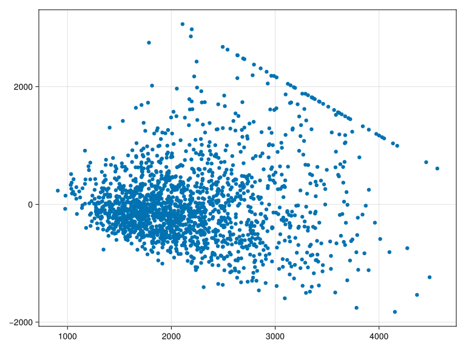

Figure 5: Residuals versus fitted values for model m4

```julia
scatter(fitted(m4), residuals(m4))
```

*This page was rendered from git revision [962c418](https://github.com/RePsychLing/SMLP2026/tree/962c418  
) using Quarto 1.9.36.*

Back to top